# Economic and Population Hardship Related to Severe Weather in the United States

## Synopsis

The goal of this analysis is to take a look at extreme weather conditions that exist in the United States to discern which types of Events are most harmful economically and to the health of the population. I quantified harm to the population in fatalities and economic hardship by the sum of crop and property damage. I chose to quantify Economic Hardship as Property Damage and Crop Damage because those were the two variables in the data set that had an explicit relationship to loss of value. I chose to quantify harm to population health as the fatality rate as there is too much variablity around injury ( they could be both minor and major), so, to control for this, I chose simply deaths. To measure both economic and health impact, I took the sum of all of the loss (whether dollar value or in terms of loss of life) during the timeframe I was observing. In this analysis, I only looked at extreme weather events since the start of 2000, as those event were the most consistently catalogued. Since the beginning of this dataset was 1950 and all of the earlier dates had incomplete data, I chose to ignore anything before January 1, 2000. What I found is that the most destructive events, in descending order, are as follows:

Destructive in terms of Economic impact:

1. Flood
2. Hurricane/Typhoon
3. Storm Surge
4. Tornado
5. Hail

Destructive in terms of loss of life:

1. Tornado
2. Execessive Heat
3. Flash Flood
4. Lightning
5. Rip Current

## Data Processing

The following code will set the appropriate working directory:

```r
setwd("~/Repository/Coursera/RepResearch_Assign2")
```

===============================================================================

PLEASE NOTE: In my original analysis, I used the following code block to download the file from the Internet:

- url <- “https://d396qusza40orc.cloudfront.net/repdata%2Fdata%2FStormData.csv.bz2”
- destfile <- “Storm_Data.csv.bz2”
- download.file(url=url, destfile=destfile, method=“curl”)

For some reason which I cannot surmise, when I tried running the code again, it does not download the entire file. Instead, it stops after only a second or 2 and gives no error message. As a result, I am removing this code from my Doc and will walk through how to perform this process manually. However, I did want to display this change of process.

===============================================================================

The following will be the manual process to download the data file from the internet and create a CSV document in the Working Directory:

1. Paste the following URL into the URL bar (without quotes): “https://d396qusza40orc.cloudfront.net/repdata%2Fdata%2FStormData.csv.bz2”
2. Rename the file (without quotes): “Storm_Data.csv.bz2”
3. Move the file to the Working Directory (in my case: “~Repository/Coursera/ RepResearch_Assign2”)

Now we will create an R Object from the CSV and only take the columns we will use in our analysis:

```r
data <- read.csv(bzfile("Storm_Data.csv.bz2"))
data <- data[,c("BGN_DATE","STATE","EVTYPE","FATALITIES","INJURIES","PROPDMG",
"PROPDMGEXP","CROPDMG","CROPDMGEXP")]
```

In order to get the best possible analysis, we will only look at the data starting at the year 2000. The justification for this, to reiterate from the Synopsis, is that the earlier documented events in history were not catalogued well and as a result cannot be trusted. The following code accomplishes this:

```r
data$BGN_DATE <- as.Date(data$BGN_DATE, format="%m/%d/%Y")
data$Event_Year <- as.numeric(format(data$BGN_DATE, "%Y"))
data <- data[data$Event_Year >= 2000, ]
```

To calculate the precise Economic Damage, we will multiply both the Crop Damage and the Property Damage columns by their multipliers. We will then add them to get the Total Economic Damage (again, please see the Synopsis for justification):

```r
data$PROPDMGEXP <- as.character(data$PROPDMGEXP)
data$PROPDMGEXP[tolower(data$PROPDMGEXP) == "b"] <- 1000000000
data$PROPDMGEXP[tolower(data$PROPDMGEXP) == "m"] <- 1000000
data$PROPDMGEXP[tolower(data$PROPDMGEXP) == "k"] <- 1000
data$PROPDMGEXP[tolower(data$PROPDMGEXP) == "h"] <- 100
data$PROPDMGEXP[data$PROPDMGEXP == ""] <- 1
data$PROPDMGEXP[data$PROPDMGEXP == "0"] <- 1

data$CROPDMGEXP <- as.character(data$CROPDMGEXP)
data$CROPDMGEXP[tolower(data$CROPDMGEXP) == "b"] <- 1000000000
data$CROPDMGEXP[tolower(data$CROPDMGEXP) == "m"] <- 1000000
data$CROPDMGEXP[tolower(data$CROPDMGEXP) == "k"] <- 1000
data$CROPDMGEXP[tolower(data$CROPDMGEXP) == "h"] <- 100
data$CROPDMGEXP[data$CROPDMGEXP == ""] <- 1
data$CROPDMGEXP[data$CROPDMGEXP == "0"] <- 1

data$Crop_Damage <- data$CROPDMG * as.numeric(data$CROPDMGEXP)
data$Prop_Damage <- data$PROPDMG * as.numeric(data$PROPDMGEXP)
data$Econ_Damage <- data$Prop_Damage + data$Crop_Damage
```

## Results

Now I will display the figure which shows the Events by greatest Economic consequences:

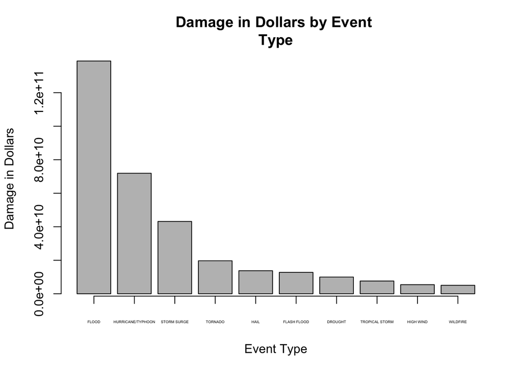

```r
econData <- aggregate(formula=Econ_Damage~EVTYPE, data=data, FUN=sum)
econData <- econData[with(econData, order(Econ_Damage, decreasing=TRUE)), ]
econData <- econData[1:10, ]

mp <- barplot(econData$Econ_Damage, axes=F, main="Damage in Dollars by Event
Type")
axis(1, at=mp, labels=econData$EVTYPE, cex.axis=0.30)
axis(2, ylim=range(0, econData$Econ_Damage))
title(xlab="Event Type")
title(ylab="Damage in Dollars")
```

Now I will display the figure which shoes the Events by greatest impact to population health:

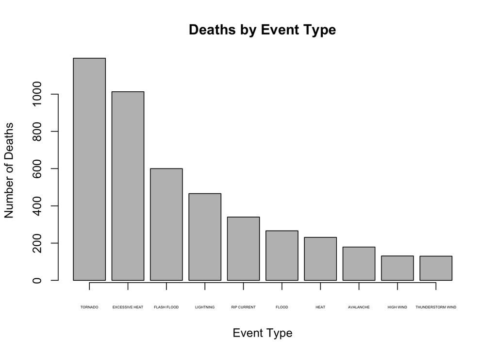

```r
popData <- aggregate(formula=FATALITIES~EVTYPE, data=data, FUN=sum)
popData <- popData[with(popData, order(FATALITIES, decreasing=TRUE)), ]
popData <- popData[1:10, ]

mp <- barplot(popData$FATALITIES, axes=F, main="Deaths by Event Type")
axis(1, at=mp, labels=popData$EVTYPE, cex.axis=0.30)
axis(2, ylim=range(0, popData$FATALITIES))
title(xlab="Event Type")
title(ylab="Number of Deaths")
```